# Optimization at the population level

John Doe

Thu May 30 09:43:47 2019

This report import the data in the COST format and do some basic quality checks.

# Tools

R, Rstudio and packages.

```r
#working directory have to be the directory where is the Rmarkdown file.

#setwd("~/ifremer/wkbioptim2/scripts/pop_level_sim_ope")

#R general option:
options(stringsAsFactors = FALSE)
#chunk option
knitr::opts_chunk$set(cache=FALSE,echo=TRUE, warning=FALSE,
    message=FALSE, fig.height=6,progress=FALSE,verbose=FALSE,
        include=TRUE,dev='png',autodep=FALSE)
#package
library(COSTcore)
library(COSTdbe)
library(COSTeda)
library(dplyr)
library(ggplot2)
library(maps)
library(mapdata)
library(pander)
library(ggrepel)
#DATRAS is not available on CRAN so use devtools:
#devtools::install_github("DTUAqua/DATRAS/DATRAS")
library(DATRAS)
#library(earthmovdist) deprecated
library(emdist)

#source local functions file
source("fct.R")
```

# Data

The data are read and imported in the COST format (a old version of Fishframe). Regarding the data submitted to the RDB, some columns have to be removed. The functions to import the data are :

- `clData()`: to import landings information,
- `ceData()`: to import effort,
- `csData()`: to import sampling data.

General methods (`head()`,`summary()`…) are available for these objects.

## A short example

Here an example using the example dataset of the sharepoint (but the chunk option `eval` is set to `FALSE`, so the code is not submitted to R):

```r
 #read CS
 tr<-read.csv("./data/TR.csv",sep=",")
 hh<-read.csv("./data/HH.csv",sep=",")
 sl<-read.csv("./data/SL.csv",sep=",")
 hl<-read.csv("./data/HL.csv",sep=",")
 ca<-read.csv("./data/CA.csv",sep=",")
 #prepare the data to the COST format
 tr<-tr[,-1]
 hh<-hh[!is.na(hh$trpCode),-1]
 sl<-sl[,-c(1,18,19)]
 hl<-hl[,-c(1,15,19)]
 CSr<-csData(tr,hh,sl,hl)
```

## Real data

Some data are available in the data directory. They are french data from the area 27.7.e and 27.7.d in 2015, 2016 and 2017 containing all the species. Pick one randomly !

The data are loaded in R:

```r
     load("./data/CLr2015_7d.rdata") #CLr
     load("./data/CEr2015_7d.rdata") #CEr
     load("./data/CSr2015_7d.rdata") #CSr
```

# Exploratory analyses

A short but intense exploratory data analyses starts in order to understand what is the information availalbe in these objects.

## Map

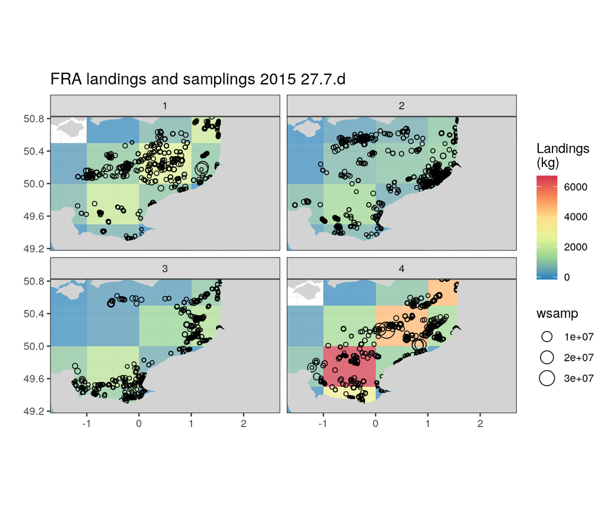

```r
#map1<-mapclcs(CLr,CSr)
#taxon by gear
    mapcl<-CLr@cl%>%
        mutate(gear=substr(foCatEu6,1,3))%>%
        group_by(rect,year,quarter)%>%
        summarise(lan=sum(landWt,na.rm=T)/1000)%>%
        ungroup()
    mapcs<-left_join(CSr@sl,CSr@hh)# %>%
    mapcs<-left_join(CSr@sl,CSr@hh) %>%
        mutate(gear=substr(foCatEu6,1,3),
               idsamp=paste(trpCode,staNum),
               quarter=ceiling(as.numeric(substr(date,6,7))/3)) %>%
        group_by(x=lonIni,y=latIni,catchCat,quarter)%>%
        summarise(wsamp=sum(wt,na.rm=T),nbsamp=n_distinct(idsamp))
    #draw a map
    mapcl$lon<-mapcl$lat<-mapcl$lonc<-mapcl$latc<-NA
    for(i in 1:nrow(mapcl)){
        if(nchar(mapcl$rect[i])==4){
        mapcl$lon[i]<-DATRAS::icesSquare2coord(mapcl$rect[i],"midpoint")$lon
        mapcl$lat[i]<-DATRAS::icesSquare2coord(mapcl$rect[i],"midpoint")$lat
        mapcl$lonc[i]<-DATRAS::icesSquare2coord(mapcl$rect[i],"corner")$lon
        mapcl$latc[i]<-DATRAS::icesSquare2coord(mapcl$rect[i],"corner")$lat
        }
    }
    rangex<-c(min(mapcl$lon,na.rm=T)-.1,max(mapcl$lon,na.rm=T)+.1)
    rangey<-c(min(mapcl$lat,na.rm=T)-.1,max(mapcl$lat,na.rm=T)+.1)
    #poly map
    map0<-ggplot(mapcl)+theme_bw()+
        geom_raster(data=mapcl,aes(x=lon,y=lat,fill=lan),stat="identity",alpha=.75)+
        geom_point(data=mapcs,aes(x=x,y=y,size=wsamp),alpha=1,shape=1)+
        borders("worldHires",xlim=rangex,ylim=rangey,fill="light grey",colour="light grey")+
        coord_quickmap(xlim=range(mapcl$lon,na.rm=T),ylim=range(mapcl$lat,na.rm=T))+
        scale_fill_distiller(palette='Spectral',name="Landings\n(kg)")+
        ggtitle(paste("FRA landings and samplings",unique(CLr@cl$year),unique(CLr@cl$area)))+
        facet_wrap(~quarter,ncol=2)+xlab("")+ylab("")
map0
```

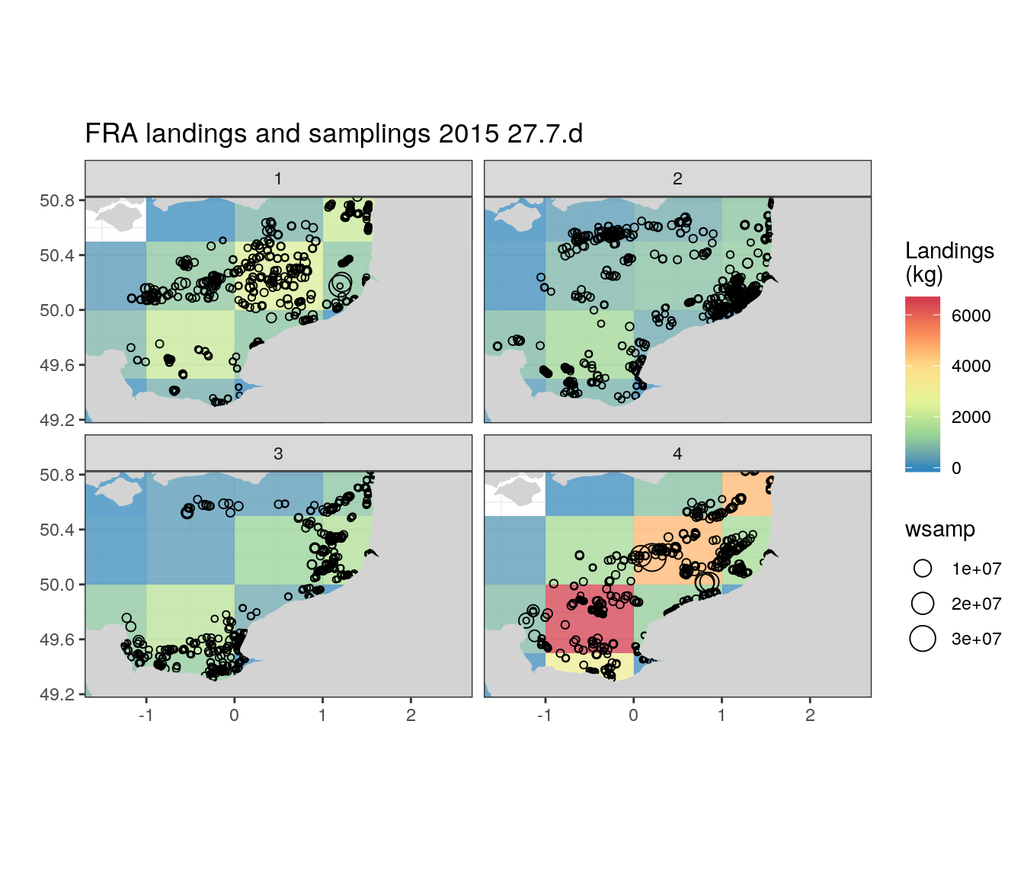

```r
print(map0)
```

```r
ggsave(file="map00.png")
```

## Species and gear

Map the landings by gear with the number of sampling.

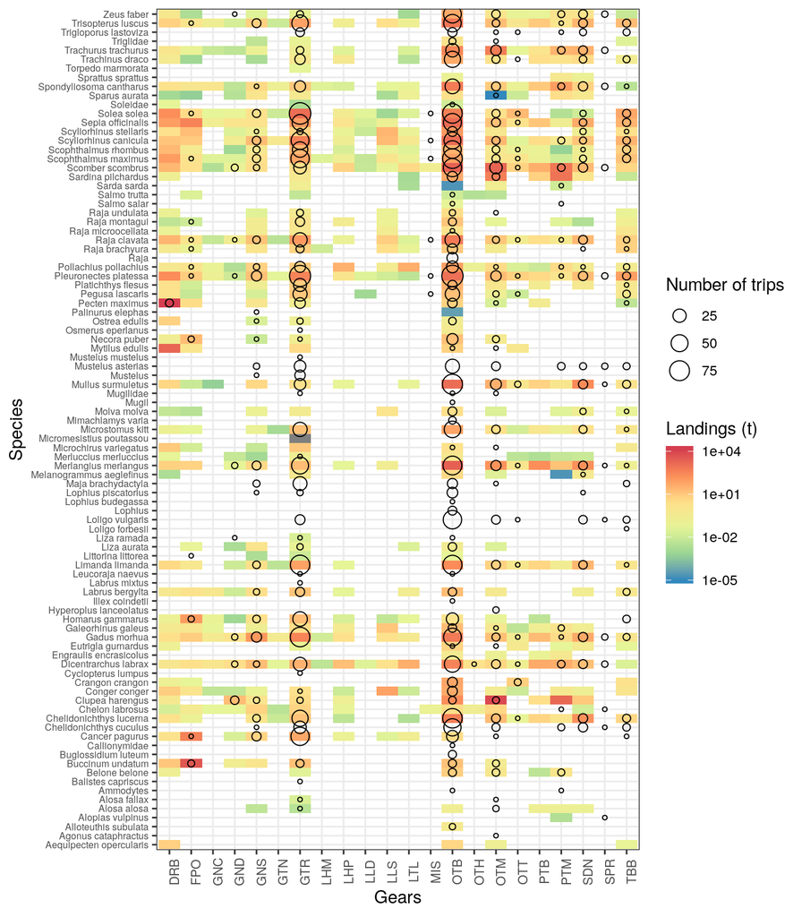

```r
#plt1<-pltsppgear(CLr,CSr)
sppgear<-CLr@cl%>%
        mutate(gear=substr(foCatEu6,1,3),spp=taxon)%>%
        group_by(gear,spp)%>%
        summarise(lan=sum(landWt,na.rm=T)/1000)%>%
        ungroup()
sppsamp<-left_join(CSr@sl,CSr@hh) %>%filter(catchCat=="LAN")%>%
        mutate(gear=substr(foCatEu6,1,3),
        idsamp=paste(trpCode))%>%
        group_by(gear,spp)%>%
        summarise(sampw=sum(wt,na.rm=T)/1000,nbsamp=n_distinct(idsamp))%>%
        ungroup()
#a plot
p1<-ggplot()+
        geom_raster(data=sppgear,aes(x=gear,y=spp,fill=lan))+
                                scale_fill_distiller(palette='Spectral',name="Landings (t)",trans="log10")+
        geom_point(data=sppsamp,aes(x=gear,y=spp,size=nbsamp),shape=1)+
        scale_size(name="Number of trips")+
    xlab("Gears")+ylab("Species")+
        theme_bw()+
        theme(axis.text.x = element_text(size=8, angle=90),
                axis.text.y = element_text(size=6, angle=0),
                strip.text.x=element_text(size=8,angle=90),
        strip.text.y=element_text(size=8,angle=0),
        #legend.position="bottom",
    )
print(p1)
```

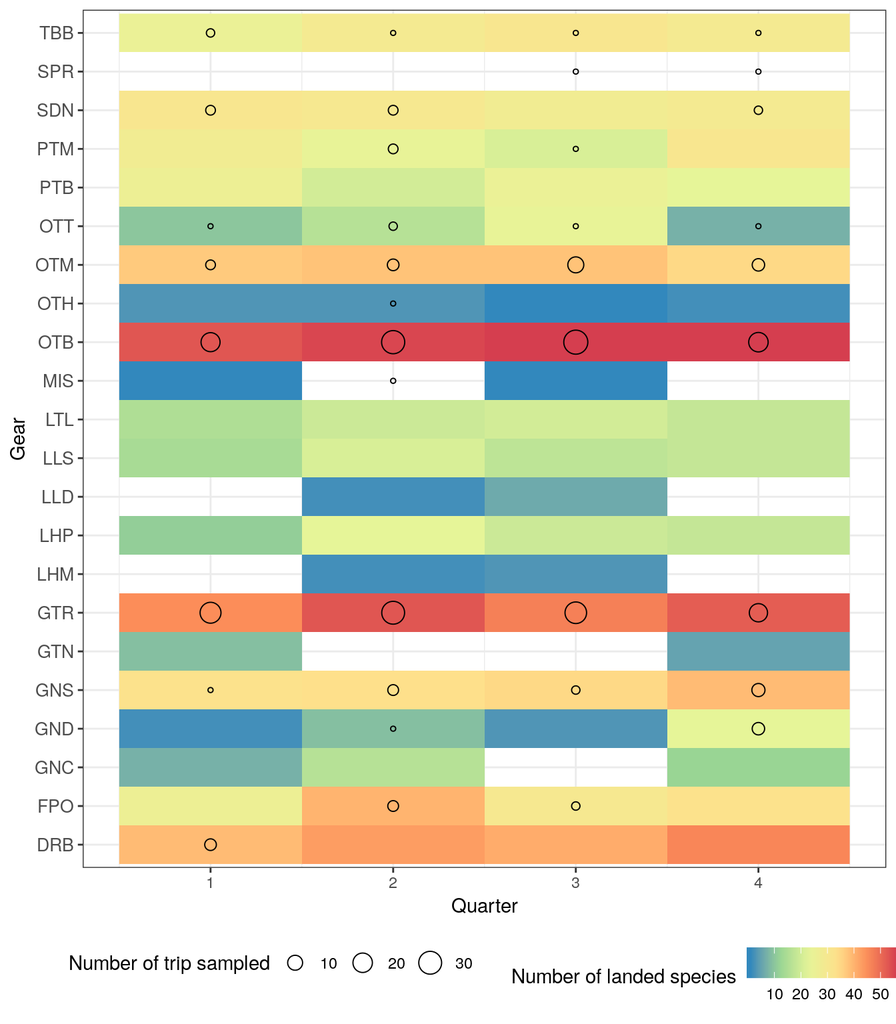

```r
ggsave(file="sppgear0.png")

#map nb of sampling and landings by gear/quarter
trimgearlan<-CLr@cl%>%
        mutate(gear=substr(foCatEu6,1,3),quarter,spp=taxon)%>%
        group_by(gear,quarter)%>%
        summarise(lan=sum(landWt,na.rm=T)/1000,nbspp=n_distinct(spp))%>%
        ungroup()
trimgearsamp<-left_join(CSr@sl,CSr@hh) %>%
        mutate(gear=substr(foCatEu6,1,3),quarter=ceiling(as.numeric(substr(date,6,7))/3),
        idsamp=paste(trpCode))%>%
        group_by(gear,quarter)%>%
        summarise(sampw=sum(wt,na.rm=T)/1000,nbsamp=n_distinct(idsamp),nbspp=n_distinct(spp))%>%
        ungroup()
#a plot
p1<-ggplot()+
        geom_raster(data=trimgearlan,aes(x=quarter,y=gear,fill=nbspp))+
                                scale_fill_distiller(palette='Spectral',name="Number of landed species")+
        geom_point(data=trimgearsamp,aes(x=quarter,y=gear,size=nbsamp),shape=1)+
        scale_size(name="Number of trip sampled")+
    xlab("Quarter")+ylab("Gear")+
        theme_bw()+
        theme(#axis.text.x = element_text(size=8, angle=90),
                axis.text.y = element_text(size=10, angle=0),
                strip.text.x=element_text(size=8,angle=90),
        strip.text.y=element_text(size=8,angle=0),
        legend.position="bottom")
print(p1)
```

```r
ggsave(file="trimgear1.png")
#select gear
listgear<-trimgearsamp%>%group_by(gear)%>%mutate(test=n_distinct(quarter))%>%filter(test==4)%>%select(gear)%>%distinct()

CLr<-subset(CLr,substr(foCatEu6,1,3)%in%listgear$gear)
CSr<-subset(CSr,substr(foCatEu6,1,3)%in%listgear$gear,table="hh")
```

To much information ! Use the most landed and sampled species.

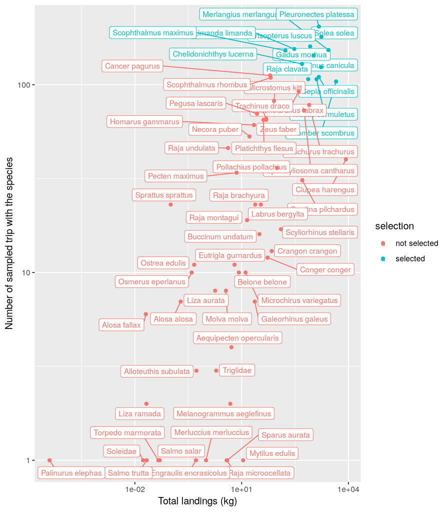

```r
#not usable: work on the species the most landed
lantot<-CLr@cl%>%
    group_by(spp=taxon)%>%
    summarise(lan=sum(landWt,na.rm=T)/1000)%>%
    ungroup()
samptot<-left_join(CSr@sl,CSr@hh) %>%
    mutate(idsamp=paste(trpCode))%>%
    group_by(spp)%>%
    summarise(nbsamp=n_distinct(idsamp))%>%
    ungroup()
all<-full_join(lantot,samptot)%>%arrange(desc(lan),desc(nbsamp))%>%
    mutate(selection=ifelse(nbsamp>100&lan>100,"selected","not selected"))
p1<-ggplot(all,aes(x=lan,y=nbsamp,label=spp,color=selection))+
    geom_label_repel(size=3)+
    geom_point()+
    xlab("Total landings (kg)")+
    ylab("Number of sampled trip with the species")+
    scale_y_log10()+
    scale_x_log10()
print(p1)
```

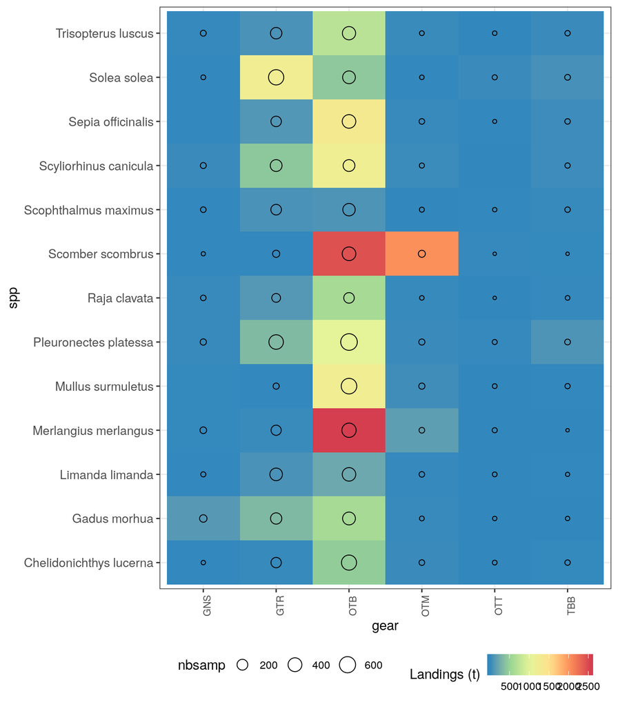

```r
ggsave(file="sppselection.png")

#select the species
#all%>%filter(nbsamp>100&lan>500)
listspp<-all%>%filter(selection=="selected")
#subset the data
CLr<-subset(CLr,taxon%in%listspp$spp)
CSr<-subset(CSr,spp%in%listspp$spp,table="sl")
#susbet by gear
#CLr<-subset(CLr,substr(foCatEu6,1,3)%in%"OTB")
#CLr<-subset(CSr,substr(foCatEu6,1,3)%in%"OTB",table="hh")

#check the new data
plt2<-pltsppgear(CLr,CSr)

print(plt2)
```

```r
ggsave(file="sppgearfinal.png")
```

Looks fine now !

# Stratification

The temporal, spatial and technical stratification is defined here:

- space: ICES division,
- time: quarter,
- technical: gear (to avoid the tremendous metier conversion to ICES reference table).

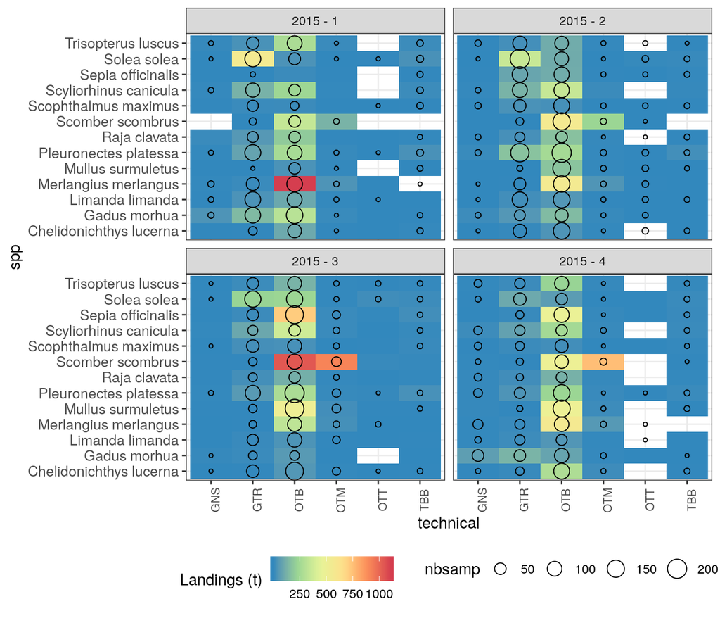

```r
#compute the length distribution
met<-data.frame(old=sort(unique(c(CLr@cl$foCatEu6,CSr@hh$foCatEu6))),new="other")%>%
        mutate(new=substr(old,1,3))
myStr<-strIni(timeStrata="quarter", techStrata='foCatEu6',spaceStrat='area',
              tcRec=list(from=met$old,to=met$new))
CSv<-csDataVal(CSr)
CSc<-csDataCons(CSv,myStr)
CLv<-clDataVal(CLr)
CLc<-clDataCons(CLv,myStr)
CEv<-ceDataVal(CEr)
CEc<-ceDataCons(CEv,myStr)
#check
p1<-pltsppgearcons(CLc,CSc)
plot(p1)
```

```r
ggsave(file="sppstratif.png")
#save the data with extra data
save(CLc,CEc,CSc,myStr,listspp,file="./data/dataready.rdata")
```

# Estimation

## Examples

### Raising to the trip

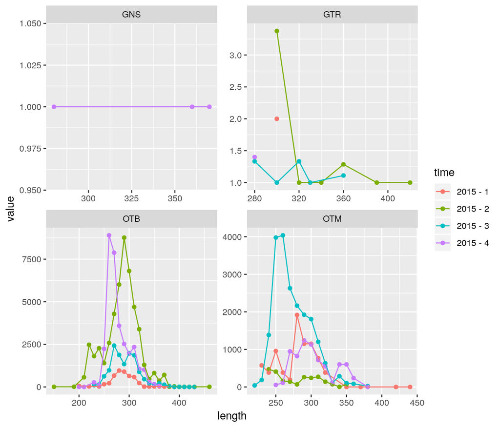

```r
dbelan1<-dbeObject(species=listspp$spp[1],catchCat='LAN',strataDesc=myStr)
dbelan1<-RaiseLgth(dbelan1,CSc)
#plot the length distribution
p1<-pltlendbe(dbelan1)
print(p1)
```

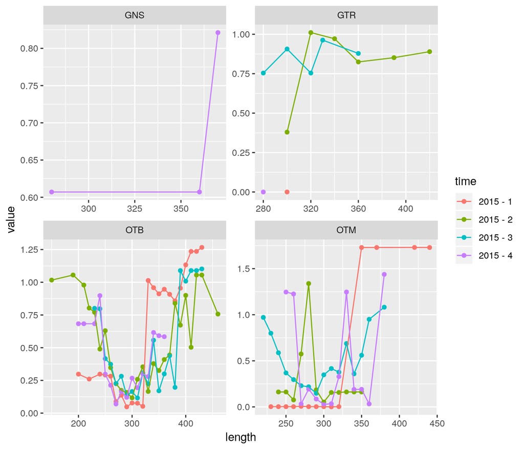

```r
#plot the cv distribution
p1<-pltcvdbe(dbelan1)
print(p1)
```

```r
#weighted cv
print(dbelan1@lenNum$DCRcvIndicator)
```

```
## [1] 0.2414598
```

### Raising to the total landings

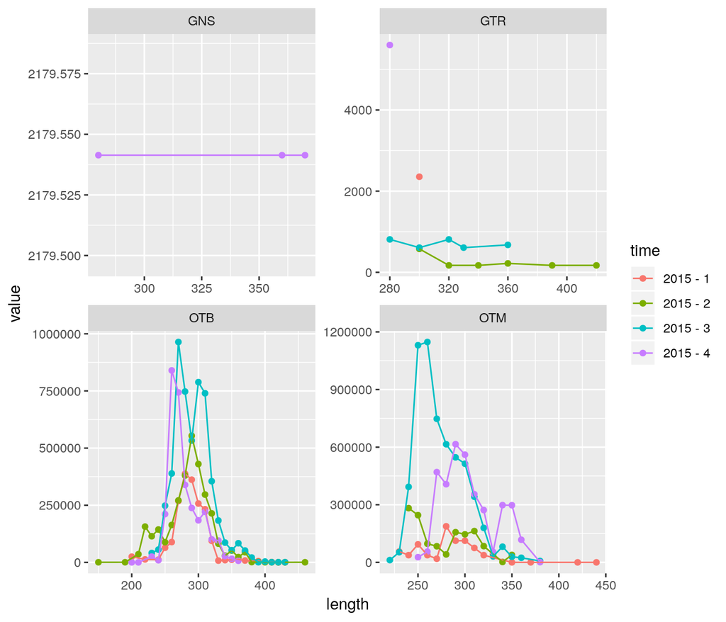

```r
dbelan1<-dbeObject(species=listspp$spp[1],catchCat='LAN',strataDesc=myStr)
dbelan1<-RaiseLgth(dbelan1,CSc,CLc)
#plot the length distribution
p1<-pltlendbe(dbelan1)
print(p1)
```

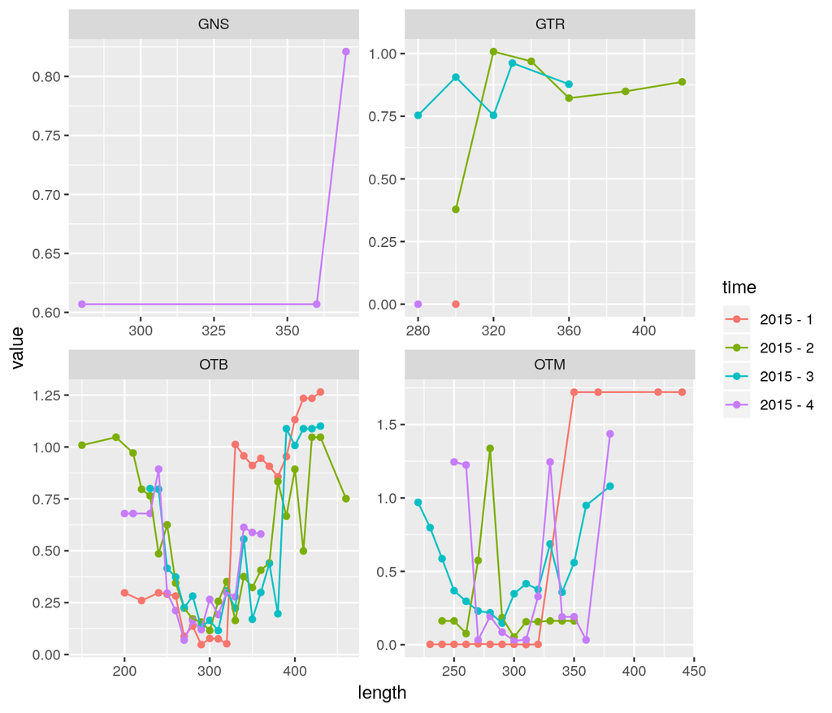

```r
#plot the cv distribution
p1<-pltcvdbe(dbelan1)
print(p1)
```

```r
#weighted cv
print(dbelan1@lenNum$DCRcvIndicator)
```

```
## [1] 0.2336632
```